# A song of ice and fire (books 1 to 5) community detection

Rafaela Becerra

# 1 A song of ice and fire (books 1 to 5) network

## 1.1 Packages needed

```r
set.seed(123)
library(igraph)
```

## 1.2 Load the network.

```r
setwd("C:/Users/Rafaela Becerra/Desktop/UC3M/Network_Analysis/Assignments/Starwars")
load("GoT.RData")
got.network <- union_edges
```

```r
got.network <-graph_from_data_frame(union_edges,directed=TRUE,vertices=NULL)
gsize(got.network)
```

```
## [1] 404
```

```r
gorder(got.network)
```

```
## [1] 208
```

```r
data <- as_data_frame(got.network)
```

## 1.3 Cliques of the network, as well as the graph coreness.

### 1.3.1 Cliques

```r
got.network.cliques <- cliques(got.network)
length(got.network.cliques)
```

```
## [1] 639
```

```r
table(sapply(got.network.cliques,length))
```

```
##
##   1   2   3
## 208 326 105
```

```r
head(largest_cliques(got.network))
```

```
## [[1]]
## + 3/208 vertices, named, from 51baf6c:
## [1] Loras Tyrell     Alerie Hightower Mace Tyrell
##
## [[2]]
## + 3/208 vertices, named, from 51baf6c:
## [1] Willas Tyrell    Alerie Hightower Mace Tyrell
##
## [[3]]
## + 3/208 vertices, named, from 51baf6c:
## [1] Horas Redwyne  Mina Tyrell    Paxter Redwyne
##
## [[4]]
## + 3/208 vertices, named, from 51baf6c:
## [1] Hobber Redwyne Mina Tyrell    Paxter Redwyne
##
## [[5]]
## + 3/208 vertices, named, from 51baf6c:
## [1] Elinor Tyrell   Lia Serry       Theodore Tyrell
##
## [[6]]
## + 3/208 vertices, named, from 51baf6c:
## [1] Medwick Tyrell             Elyn Norridge
## [3] Luthor Tyrell son of Moryn
```

```r
got.network.max.cliques <- max_cliques(got.network)
table(sapply(got.network.max.cliques,length))
```

```
##
##   2   3
##  74 105
```

Recall that this network contains as the vertices the characters of the books from the A song of ice and fire series, and presents by the edges the relationship among them of “mother”,“father”, and “spouse” being a directed graph considering that the arcs contain directions. A clique can be understood as a complete subgraph were its vertices are totally connected, for this to happend in the network we will be facing an omission of the direction of the relations. Considering this set, there are a total of 639 cliques, with sizes 1, 208, size 2, 326, and, size 3 105. By the nature of the data and by taking a look at the results we can confirmed that the maximum size cliques will be given by father, mother and child, because is the type of relation that will allow the vertices to connect to each other fully. Moreover, we check the maximal number of cliques to see if the rest of the cliques are just subgraphs of these ones. As we can see, 74 out of the 326 correspond to the maximal size cliques, this means that 74 out of the 326 are spouse relations with children.

### 1.3.2 Coreness

```r
got.network.cores <- graph.coreness(got.network,mode="all")
got.network.cores
```

```
##                            Lysa Arryn                          Jasper Arryn
##                                     2                                     2
##                             Jon Arryn                      Cersei Lannister
##                                     2                                     4
##                     Cassana Baratheon                        Selyse Florent
##                                     4                                     2
##                     Rhaelle Targaryen                      Robert Baratheon
##                                     3                                     4
##                     Steffon Baratheon                     Stannis Baratheon
##                                     4                                     2
##                      Ormund Baratheon                       Jaime Lannister
##                                     3                                     4
##                          Mariya Darry                       Genna Lannister
##                                     3                                     3
##                         Bethany Rosby                           Jeyne Darry
##                                     3                                     2
##                           Perra Royce                           Dorna Swyft
##                                     3                                     3
##                      Amarei Crakehall                          Merrett Frey
##                                     3                                     3
##                            Emmon Frey                           Walder Frey
##                                     3                                     3
##                            Cleos Frey                       Kevan Lannister
##                                     2                                     3
##               Lady of House Stonetree                   Lady of House Piper
##                                     2                                     2
##                Lady of House Sunderly                        Alannys Harlaw
##                                     2                                     2
##                       Quellon Greyjoy                         Balon Greyjoy
##                                     2                                     2
##                         Marla Prester                       Alys Stackspear
##                                     3                                     2
##                          Cerissa Brax                       Myranda Lefford
##                                     3                                     2
##                        Rohanne Webber                      Shiera Crakehall
##                                     3                                     2
##                     Darlessa Marbrand                      Joanna Lannister
##                                     2                                     4
##                        Jeyne Marbrand                        Ella Lannister
##                                     3                                     2
```

[output cut: 153 more lines]

```
##                                     1                                     1
##                            Arya Stark                            Bran Stark
##                                     2                                     2
##                          Benjen Stark                              Jon Snow
##                                     2                                     3
##                          Rickon Stark                  Brandon Stark Burner
##                                     2                                     1
##                     Viserys Targaryen         Luthor Tyrell son of Theodore
##                                     2                                     2
##                        Medwick Tyrell                         Elinor Tyrell
##                                     2                                     2
##                        Hobber Redwyne                         Horas Redwyne
##                                     2                                     2
##                         Willas Tyrell                          Loras Tyrell
##                                     2                                     2
```

Next, we have calculated the coreness which returns the maximal k-core for the set of vertices of the graph. We can see that the maximum number of this measure is 4, which means that considering directions there are characters that connect with at least 4 other characters. The characters that meet this condition are Cersei Lannister, Cassana Baratheon, Robert Baratheon, Steffon Baratheon, Jaime Lannister, Joanna Lannister, Tywin Lannister, Tommen Baratheon, Joffrey Baratheon, Margaery Tyrell, and Renly Baratheon. Additionally, we present a histogram with the results of the k-core, as we can see, most of the characters are part of a subgraph with no more than 2 join vertices, which confirms that the network is not dense. This is understandable because the data contains just three types of relationships, then it can not be expected to have a large number of connections among the characters.

```r
max(got.network.cores)
```

```
## [1] 4
```

```r
which(got.network.cores==max(got.network.cores))
```

```
##  Cersei Lannister Cassana Baratheon  Robert Baratheon Steffon Baratheon
##                 4                 5                 8                 9
##   Jaime Lannister  Joanna Lannister   Tywin Lannister  Tommen Baratheon
##                12                38                47               101
## Joffrey Baratheon   Margaery Tyrell   Renly Baratheon
##               102               103               104
```

```r
length(which(got.network.cores==max(got.network.cores)))
```

```
## [1] 11
```

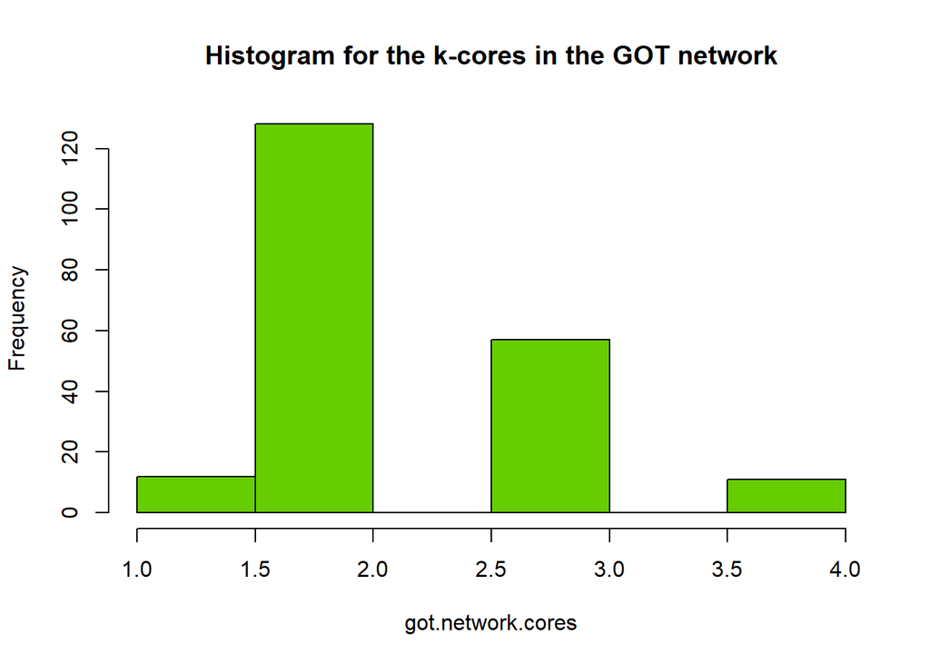

```r
hist(got.network.cores,
     col="chartreuse3",
     main="Histogram for the k-cores in the GOT network")
```

## 1.4 Density and the clustering coefficient (transitivity) of the network.

### 1.4.1 Density

```r
sim.got.network <- simplify(got.network)

print(paste('Density of GOT network: ',edge_density(sim.got.network)))
```

```
## [1] "Density of GOT network:  0.00938312894834634"
```

```r
ego.1 <- make_ego_graph(sim.got.network,order=1,
                        nodes=which(V(sim.got.network)$name=="Cersei Lannister"))
print(paste('Density of the ego network of Cersei Lannister: ',edge_density(ego.1[[1]])))
```

```
## [1] "Density of the ego network of Cersei Lannister:  0.285714285714286"
```

```r
ego.2 <- make_ego_graph(sim.got.network,order=1,
                        nodes=which(V(sim.got.network)$name=="Cassana Baratheon"))
print(paste('Density of the ego network of Cassana Baratheon: ',edge_density(ego.2[[1]])))
```

```
## [1] "Density of the ego network of Cassana Baratheon:  0.4"
```

```r
ego.3 <- make_ego_graph(sim.got.network,order=1,
                        nodes=which(V(sim.got.network)$name=="Robert Baratheon"))
print(paste('Density of the ego network of Robert Baratheon: ',edge_density(ego.3[[1]])))
```

```
## [1] "Density of the ego network of Robert Baratheon:  0.285714285714286"
```

```r
ego.4 <- make_ego_graph(sim.got.network,order=1,
                        nodes=which(V(sim.got.network)$name=="Steffon Baratheon"))
print(paste('Density of the ego network of Steffon Baratheon: ',edge_density(ego.4[[1]])))
```

```
## [1] "Density of the ego network of Steffon Baratheon:  0.285714285714286"
```

```r
ego.5 <- make_ego_graph(sim.got.network,order=1,
                        nodes=which(V(sim.got.network)$name=="Jaime Lannister"))
print(paste('Density of the ego network of Jaime Lannister: ',edge_density(ego.5[[1]])))
```

```
## [1] "Density of the ego network of Jaime Lannister:  0.233333333333333"
```

```r
ego.6 <- make_ego_graph(sim.got.network,order=1,
                        nodes=which(V(sim.got.network)$name=="Joanna Lannister"))
print(paste('Density of the ego network of Joanna Lannister: ',edge_density(ego.6[[1]])))
```

```
## [1] "Density of the ego network of Joanna Lannister:  0.285714285714286"
```

```r
ego.7 <- make_ego_graph(sim.got.network,order=1,
                        nodes=which(V(sim.got.network)$name=="Tywin Lannister"))
print(paste('Density of the ego network of Tywin Lannister: ',edge_density(ego.7[[1]])))
```

```
## [1] "Density of the ego network of Tywin Lannister:  0.285714285714286"
```

```r
ego.8 <- make_ego_graph(sim.got.network,order=1,
                        nodes=which(V(sim.got.network)$name=="Tommen Baratheon"))
print(paste('Density of the ego network of Tommen Baratheon: ',edge_density(ego.8[[1]])))
```

```
## [1] "Density of the ego network of Tommen Baratheon:  0.35"
```

```r
ego.9 <- make_ego_graph(sim.got.network,order=1,
                        nodes=which(V(sim.got.network)$name=="Margaery Tyrell"))
print(paste('Density of the ego network of Margaery Tyrell: ',edge_density(ego.9[[1]])))
```

```
## [1] "Density of the ego network of Margaery Tyrell:  0.333333333333333"
```

```r
ego.10 <- make_ego_graph(sim.got.network,order=1,
                         nodes=which(V(sim.got.network)$name=="Renly Baratheon"))
print(paste('Density of the ego network of Renly Baratheon: ',edge_density(ego.9[[1]])))
```

```
## [1] "Density of the ego network of Renly Baratheon:  0.333333333333333"
```

```r
ego.11 <- make_ego_graph(sim.got.network,order=1,
                         nodes=which(V(sim.got.network)$name=="Joffrey Baratheon"))
print(paste('Density of the ego network of Joffrey Baratheon: ',edge_density(ego.9[[1]])))
```

```
## [1] "Density of the ego network of Joffrey Baratheon:  0.333333333333333"
```

We have calculated the density for the GOT Network, which results in a value of 0.00938. The density measurement can be understood as the percentage of edges that are being taken into account in the network from the total potential ones. In this case, we can see that this is a really low value but this is expected considering the data. As said before, because of the type of relationships and the directions that they have we can not expect that all the characters will connect. Consequently, in this case the density does not say much about the network just that it is not dense at all. Moreover, just to see how is the behavior of the neighborhood of each of the characters that were identify to have more connections, we are taking a look at their densities, the results show that Cassana Baratheon has the largest density of 0.4, which means that it is more densly connected than the rest.

### 1.4.2 Transitivity

```r
transitivity(got.network,type="global")
```

```
## [1] 0.2850679
```

The transitivity is a ratio that measures the number of closed triplets in the graph compare to the total number of triplets. If we take into account this measurement, we can see that the network has only 28.50% of closed triplets, this is a low value, but once again we are facing a network that is expected not to be highly connected between its characters.

## 1.5 Number of components of the network.

```r
comps.weak.got.network <- igraph::components(got.network,mode="weak")
comps.weak.got.network$no
```

```
## [1] 2
```

```r
comps.weak.got.network$csize
```

```
## [1] 189  19
```

```r
table(comps.weak.got.network$csize)
```

```
##
##  19 189
##   1   1
```

```r
max(comps.weak.got.network$csize)/vcount(got.network)
```

```
## [1] 0.9086538
```

```r
comps.strong.got.network <- igraph::components(got.network,mode="strong")
comps.strong.got.network$no
```

```
## [1] 130
```

```r
comps.strong.got.network$csize
```

```
##   [1] 1 1 2 1 2 1 1 2 1 2 2 1 1 2 1 1 2 2 1 1 1 1 2 1 1 2 1 4 1 1 1 3 2 2 2 2 2
##  [38] 2 3 2 2 1 1 1 1 2 1 1 1 3 1 1 2 2 1 1 1 1 1 1 1 1 2 1 1 1 2 1 2 2 2 2 3 3
##  [75] 2 1 1 1 2 2 1 2 2 4 1 1 1 1 1 1 1 2 1 1 1 2 1 2 1 4 1 1 1 2 2 2 1 1 2 2 1
## [112] 1 2 1 1 3 2 4 1 2 2 2 1 2 1 4 1 2 5 1
```

```r
table(comps.strong.got.network$csize)
```

```
##
##  1  2  3  4  5
## 71 47  6  5  1
```

```r
max(comps.strong.got.network$csize)/vcount(got.network)
```

```
## [1] 0.02403846
```

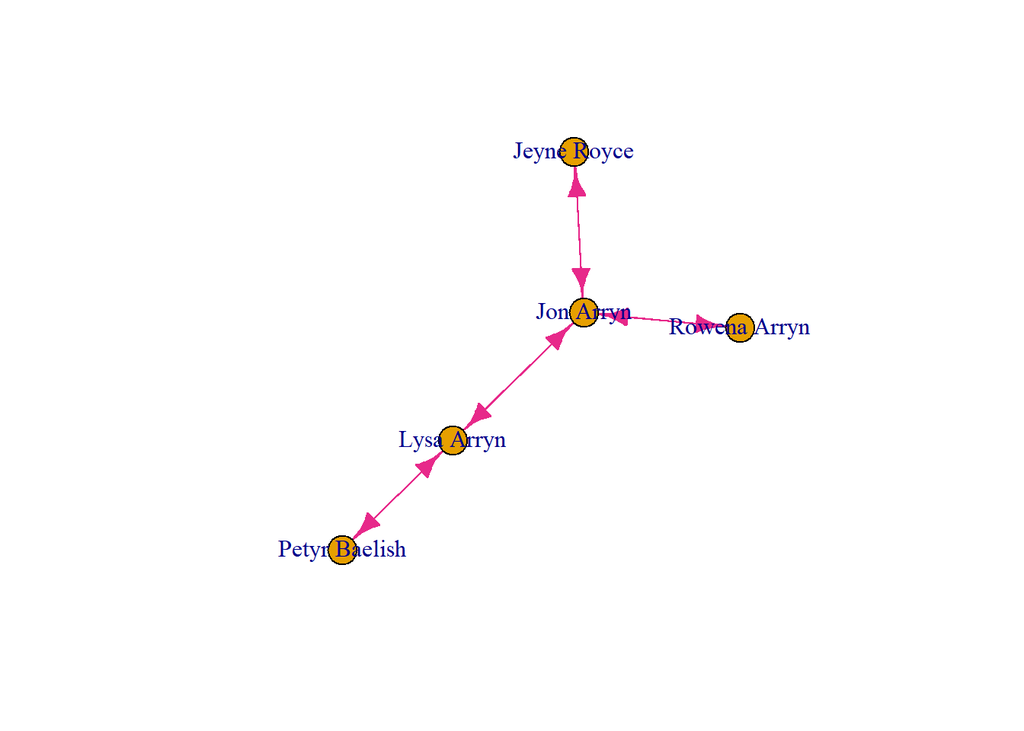

```r
gc.got.network <- induced_subgraph(got.network,vids=V(got.network)
                                   [comps.strong.got.network$membership==129])
plot.igraph(gc.got.network,
            vertex.color=V(gc.got.network)$group)
```

```r
gc.got.network
```

```
## IGRAPH 5257b7d DN-- 5 8 --
## + attr: name (v/c), type (e/c), color (e/c), lty (e/c)
## + edges from 5257b7d (vertex names):
## [1] Lysa Arryn   ->Jon Arryn     Lysa Arryn   ->Petyr Baelish
## [3] Jon Arryn    ->Lysa Arryn    Jon Arryn    ->Jeyne Royce
## [5] Jon Arryn    ->Rowena Arryn  Petyr Baelish->Lysa Arryn
## [7] Jeyne Royce  ->Jon Arryn     Rowena Arryn ->Jon Arryn
```

```r
mean_distance(gc.got.network)
```

```
## [1] 1.8
```

```r
transitivity(gc.got.network,type="global")
```

```
## [1] 0
```

[figure not shown]

```r
gc.got.network <- induced_subgraph(got.network,vids=V(got.network)
                                   [comps.strong.got.network$membership==28])
plot.igraph(gc.got.network,
            vertex.color=V(gc.got.network)$group)
```

```r
gc.got.network
```

```
## IGRAPH 527a436 DN-- 4 6 --
## + attr: name (v/c), type (e/c), color (e/c), lty (e/c)
## + edges from 527a436 (vertex names):
## [1] Maron Martell     ->Daenerys Targaryen
## [2] Daenerys Targaryen->Maron Martell
## [3] Daenerys Targaryen->Hizdahr zo Loraq
## [4] Daenerys Targaryen->Drogo
## [5] Hizdahr zo Loraq  ->Daenerys Targaryen
## [6] Drogo             ->Daenerys Targaryen
```

```r
mean_distance(gc.got.network)
```

```
## [1] 1.5
```

```r
transitivity(gc.got.network,type="global")
```

```
## [1] 0
```

[figure not shown]

```r
gc.got.network <- induced_subgraph(got.network,vids=V(got.network)[comps.strong.got.network$membership==118])
plot.igraph(gc.got.network,
            vertex.color=V(gc.got.network)$group)
```

```r
mean_distance(gc.got.network)
```

```
## [1] 1.666667
```

```r
transitivity(gc.got.network,type="global")
```

```
## [1] 0
```

[figure not shown]

```r
gc.got.network <- induced_subgraph(got.network,vids=V(got.network)
                                   [comps.strong.got.network$membership==126])
plot.igraph(gc.got.network,
            vertex.color=V(gc.got.network)$group)
```

```r
mean_distance(gc.got.network)
```

```
## [1] 1.5
```

```r
transitivity(gc.got.network,type="global")
```

```
## [1] 0
```

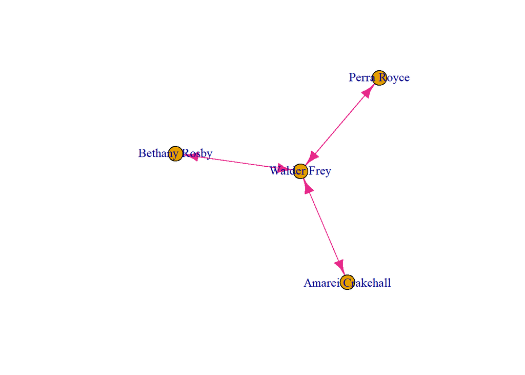

```r
gc.got.network <- induced_subgraph(got.network,vids=V(got.network)
                                   [comps.strong.got.network$membership==100])
plot.igraph(gc.got.network,
            vertex.color=V(gc.got.network)$group)
```

```r
mean_distance(gc.got.network)
```

```
## [1] 1.5
```

```r
transitivity(gc.got.network)
```

```
## [1] 0
```

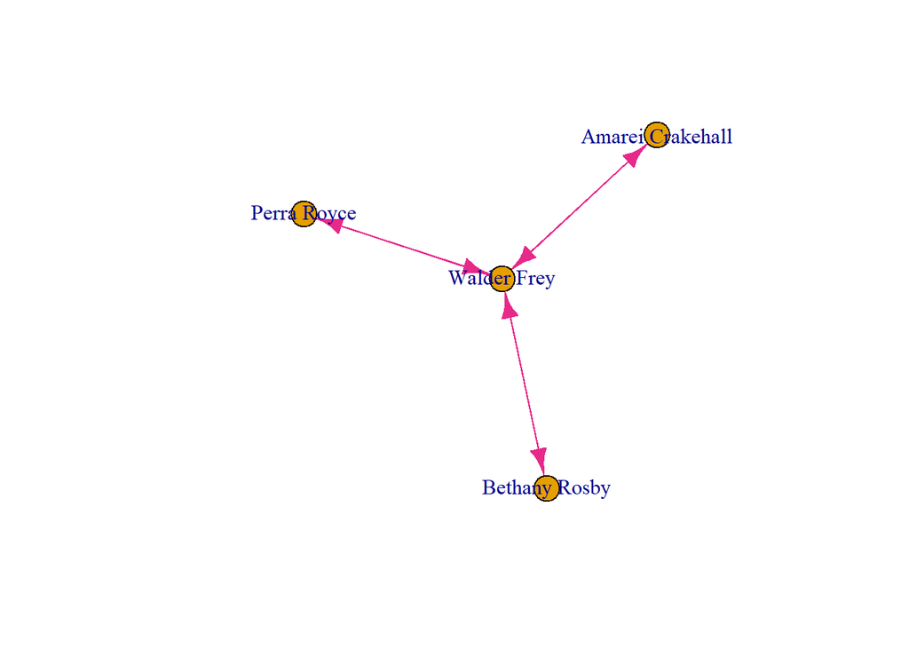

```r
gc.got.network <- induced_subgraph(got.network,vids=V(got.network)
                                   [comps.strong.got.network$membership==100])
plot.igraph(gc.got.network,
            vertex.color=V(gc.got.network)$group)
```

```r
mean_distance(gc.got.network)
```

```
## [1] 1.5
```

```r
transitivity(gc.got.network)
```

```
## [1] 0
```

The small-world property can be considered when the shortest-path distance between pairs of vertices is generally quite small, and when the clustering coefficient is relatively high. Even though, the mean distance between vertices is small, this network does not holds the Small world property considering that the clustering coefficient, by taking into account the direct paths, is almost null.

## 1.6 Community detection methods.

```r
method.compare <- setNames(data.frame(matrix(ncol = 3, nrow = 6)), c("Modularity", "K",
                                                                     "Time elapsed"))

row.names(method.compare) <- c('Optimal','Fast greedy','Louvain',
                                'Label propagation','Edge betweeness','Walktrap')
```

```r
# Transform to undirected network
und.got.network <- as.undirected(got.network,mode="each")
# Take out multiple edges and loops if they exist.
sim.und.got.network <- simplify(und.got.network)
```

### 1.6.1 Fast greedy community detection

The fast greedy is a simplified version of the maximal optimal modality which allows making faster computations to detect communities. In this case, we are taking the undirected network because this method does not take into account directions and as we can see that the number of communities resulting as optimal is 11 with a high value of modality of the partition of 0.82.

The first community is formed by 37 characters, in this group we see mostly characters of the Stark, the Arryn and the Tully family, which make sense considering that there is a relation between this families based on the fact that Hoster Tully is the father of Lysa Arryn and Catelyn Stark. In the second community with a size of 23, we see a lot of characters of the Lannister family. As well, in the third of size 18, the predominant last name is Frey, the fourth with 19 characters appear members of the Greyjoy family. In the fifth community of size 14, we can see a lot of characters with the Sand last name. In the seven community of size 16 we see members of the Tyrell family, in eight of size 14 Baratheon member, in nine with size 19 Targaryen, and in the sixth, eleven and tenth community some various last names. As proven, it seems a really good partition considering that it has taken into account the relations and separates well the characters.

```r
Start_time <- Sys.time()
got.network.fg <- cluster_fast_greedy(sim.und.got.network)
got.network.fg
```

```
## IGRAPH clustering fast greedy, groups: 11, mod: 0.82
## + groups:
##   $`1`
##    [1] "Lysa Arryn"           "Jasper Arryn"         "Jon Arryn"
##    [4] "Catelyn Stark"        "Melantha Blackwood"   "Lyarra Stark"
##    [7] "Lyanna Stark"         "Marna Locke"          "Eddard Stark"
##   [10] "Brandon Stark"        "Willam Stark"         "Rickard Stark"
##   [13] "Edwyle Stark"         "Rodrik Stark"         "Minisa Whent"
##   [16] "Hoster Tully"         "Roose Bolton"         "Alys Arryn"
##   [19] "Elys Waynwood"        "Sansa Stark"          "Tysha"
##   [22] "Tyrion Lannister"     "Jeyne Westerling"     "Talisa Stark"
##   [25] "Petyr Baelish"        "Jeyne Royce"          "Rowena Arryn"
##   + ... omitted several groups/vertices
```

```r
End_time <- Sys.time()

print(paste('Time elapsed: ', (End_time-Start_time)))
```

```
## [1] "Time elapsed:  0.00698018074035645"
```

```r
length(got.network.fg)
```

```
## [1] 11
```

```r
sizes(got.network.fg)
```

```
## Community sizes
##  1  2  3  4  5  6  7  8  9 10 11
## 37 23 18 19 14 22 16 14 19 17  9
```

```r
membership(got.network.fg)
```

```
##                            Lysa Arryn                          Jasper Arryn
##                                     1                                     1
##                             Jon Arryn                      Cersei Lannister
##                                     1                                     8
##                     Cassana Baratheon                        Selyse Florent
##                                     8                                     8
##                     Rhaelle Targaryen                      Robert Baratheon
##                                     8                                     8
##                     Steffon Baratheon                     Stannis Baratheon
##                                     8                                     8
##                      Ormund Baratheon                       Jaime Lannister
##                                     8                                     8
##                          Mariya Darry                       Genna Lannister
##                                     3                                     6
##                         Bethany Rosby                           Jeyne Darry
##                                     3                                     6
##                           Perra Royce                           Dorna Swyft
##                                     3                                     6
##                      Amarei Crakehall                          Merrett Frey
##                                     3                                     3
##                            Emmon Frey                           Walder Frey
##                                     6                                     3
##                            Cleos Frey                       Kevan Lannister
##                                     6                                     6
##               Lady of House Stonetree                   Lady of House Piper
##                                     4                                     4
##                Lady of House Sunderly                        Alannys Harlaw
##                                     4                                     4
##                       Quellon Greyjoy                         Balon Greyjoy
##                                     4                                     4
##                         Marla Prester                       Alys Stackspear
##                                     2                                     2
##                          Cerissa Brax                       Myranda Lefford
##                                     2                                     2
##                        Rohanne Webber                      Shiera Crakehall
##                                     2                                     2
##                     Darlessa Marbrand                      Joanna Lannister
##                                     6                                     2
##                        Jeyne Marbrand                        Ella Lannister
##                                     6                                     2
```

[output cut: 153 more lines]

```
##                                     5                                     5
##                            Arya Stark                            Bran Stark
##                                     1                                     1
##                          Benjen Stark                              Jon Snow
##                                     1                                     1
##                          Rickon Stark                  Brandon Stark Burner
##                                     1                                     1
##                     Viserys Targaryen         Luthor Tyrell son of Theodore
##                                     9                                    11
##                        Medwick Tyrell                         Elinor Tyrell
##                                    11                                    11
##                        Hobber Redwyne                         Horas Redwyne
##                                     7                                     7
##                         Willas Tyrell                          Loras Tyrell
##                                     7                                     7
```

```r
modularity(got.network.fg)
```

```
## [1] 0.8234173
```

```r
method.compare[2,1]<- modularity(got.network.fg)
method.compare[2,2]<- length(sizes(got.network.fg))
method.compare[2,3]<-(End_time-Start_time)
```

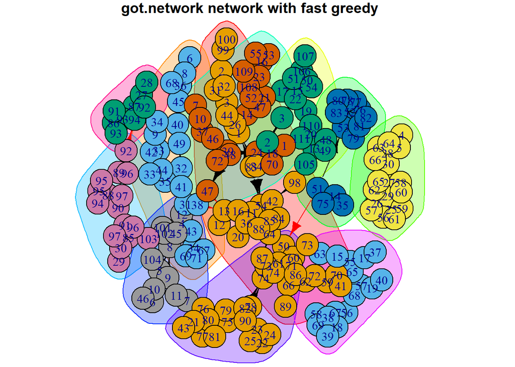

```r
par(mar=c(0,0,1,1))
plot(got.network.fg,
     got.network,
     vertex.color=membership(got.network.fg),
     vertex.label=seq(1:111),
     #vertex.label=NA,
     main="got.network network with fast greedy")
```

### 1.6.2 Louvain community detection

The Louvain community detection method is similar to the optimal modularity but the optimization is done using a hierarchical approach. In this case, we are considering the undirected network as same as before. The results for this method show that the optimal number of communities is 14, 3 more than the Fast greedy. Now the modularity increases to 0.8501 compared to the past method.

The characters have been partitioned into similar number sizes, comparing to the presented above, in this case, there is a break of a group, as we can see the Starks and the Arryn are now in separate groups, the Arryn family lays in the tenth community, and the Stark members in number 12, mostly. The sizes of these communities correspond to 13 and 18. Moreover, we can see a separation of the Tyrell family members, and also other families like the Frey, Martell present this behavior. Furthermore, the smaller communities are the fourth and the eight with 9 characters.

```r
Start_time <- Sys.time()
got.network.lo <- cluster_louvain(und.got.network)
got.network.lo
```

```
## IGRAPH clustering multi level, groups: 14, mod: 0.85
## + groups:
##   $`1`
##    [1] "Rhaelle Targaryen"
##    [2] "Ormund Baratheon"
##    [3] "Elia Martell"
##    [4] "Rhaegar Targaryen"
##    [5] "Shaera Targaryen"
##    [6] "Betha Blackwood"
##    [7] "Dyanna Dayne"
##    [8] "Rhaella Targaryen"
##    [9] "Jaehaerys II Targaryen"
##   + ... omitted several groups/vertices
```

```r
End_time <- Sys.time()

print(paste('Time elapsed: ', (End_time-Start_time)))
```

```
## [1] "Time elapsed:  0.0239379405975342"
```

```r
length(got.network.lo)
```

```
## [1] 14
```

```r
sizes(got.network.lo)
```

```
## Community sizes
##  1  2  3  4  5  6  7  8  9 10 11 12 13 14
## 22 15 12  9 19 22 17  9 15 13 11 18 12 14
```

```r
membership(got.network.lo)
```

```
##                            Lysa Arryn                          Jasper Arryn
##                                    10                                    10
##                             Jon Arryn                      Cersei Lannister
##                                    10                                     2
##                     Cassana Baratheon                        Selyse Florent
##                                     2                                     2
##                     Rhaelle Targaryen                      Robert Baratheon
##                                     1                                     2
##                     Steffon Baratheon                     Stannis Baratheon
##                                     2                                     2
##                      Ormund Baratheon                       Jaime Lannister
##                                     1                                     2
##                          Mariya Darry                       Genna Lannister
##                                     3                                     7
##                         Bethany Rosby                           Jeyne Darry
##                                     4                                     7
##                           Perra Royce                           Dorna Swyft
##                                     4                                     3
##                      Amarei Crakehall                          Merrett Frey
##                                     4                                     3
##                            Emmon Frey                           Walder Frey
##                                     7                                     4
##                            Cleos Frey                       Kevan Lannister
##                                     7                                     3
##               Lady of House Stonetree                   Lady of House Piper
##                                     5                                     5
##                Lady of House Sunderly                        Alannys Harlaw
##                                     5                                     5
##                       Quellon Greyjoy                         Balon Greyjoy
##                                     5                                     5
##                         Marla Prester                       Alys Stackspear
##                                     6                                     6
##                          Cerissa Brax                       Myranda Lefford
##                                     6                                     6
##                        Rohanne Webber                      Shiera Crakehall
##                                     6                                     6
##                     Darlessa Marbrand                      Joanna Lannister
##                                     7                                     2
##                        Jeyne Marbrand                        Ella Lannister
##                                     7                                     6
```

[output cut: 153 more lines]

```
##                                    14                                    14
##                            Arya Stark                            Bran Stark
##                                    13                                    13
##                          Benjen Stark                              Jon Snow
##                                    12                                     1
##                          Rickon Stark                  Brandon Stark Burner
##                                    13                                    12
##                     Viserys Targaryen         Luthor Tyrell son of Theodore
##                                     1                                     8
##                        Medwick Tyrell                         Elinor Tyrell
##                                     8                                     8
##                        Hobber Redwyne                         Horas Redwyne
##                                     9                                     9
##                         Willas Tyrell                          Loras Tyrell
##                                     9                                     9
```

```r
modularity(got.network.lo)
```

```
## [1] 0.8501893
```

```r
method.compare[3,1]<- modularity(got.network.lo)
method.compare[3,2]<- length(sizes(got.network.lo))
method.compare[3,3]<-(End_time-Start_time)
```

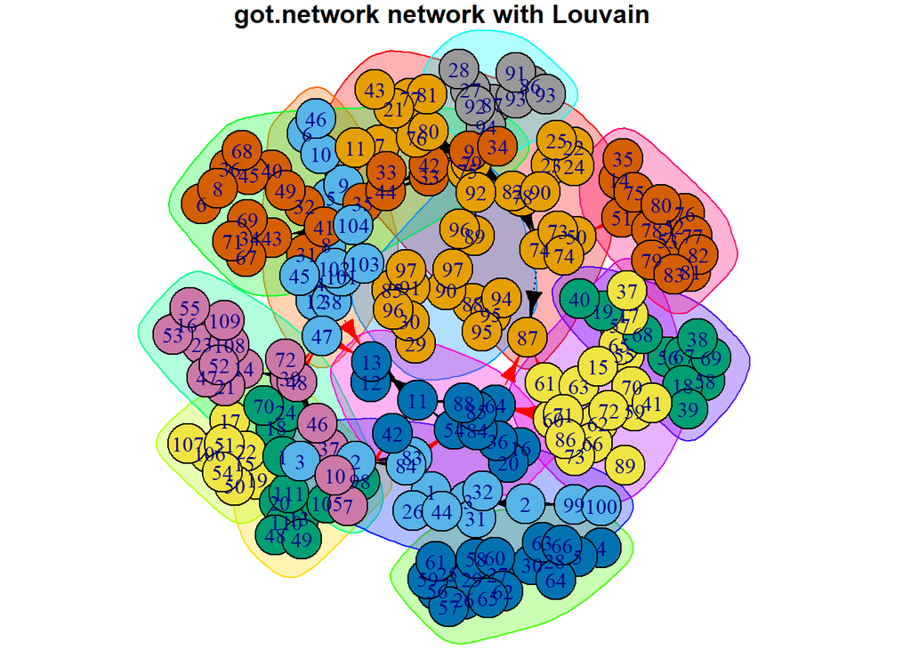

```r
par(mar=c(0,0,1,1))
plot(got.network.lo,
     got.network,
     vertex.color=membership(got.network.fg),
     vertex.label=seq(1:111),
     #vertex.label=NA,
     main="got.network network with Louvain")
```

### 1.6.3 Label propagation community detection

```r
Start_time <- Sys.time()
got.network.lp <- cluster_label_prop(und.got.network,
                                     initial=as.vector(membership(got.network.lo)))
got.network.lp
```

```
## IGRAPH clustering label propagation, groups: 14, mod: 0.85
## + groups:
##   $`1`
##    [1] "Lysa Arryn"    "Jasper Arryn"  "Jon Arryn"     "Minisa Whent"
##    [5] "Hoster Tully"  "Alys Arryn"    "Elys Waynwood" "Edmure Tully"
##    [9] "Roslin Frey"   "Petyr Baelish" "Jeyne Royce"   "Rowena Arryn"
##   [13] "Robert Arryn"
##
##   $`2`
##    [1] "Cersei Lannister"   "Cassana Baratheon"  "Selyse Florent"
##    [4] "Robert Baratheon"   "Steffon Baratheon"  "Stannis Baratheon"
##    [7] "Jaime Lannister"    "Joanna Lannister"   "Tywin Lannister"
##   + ... omitted several groups/vertices
```

```r
End_time <- Sys.time()

print(paste('Time elapsed: ', (End_time-Start_time)))
```

```
## [1] "Time elapsed:  0.00697994232177734"
```

```r
length(got.network.lp)
```

```
## [1] 14
```

```r
sizes(got.network.lp)
```

```
## Community sizes
##  1  2  3  4  5  6  7  8  9 10 11 12 13 14
## 13 15 22 12 17  9 19 22 14 12 18 11 15  9
```

```r
membership(got.network.lp)
```

```
##                            Lysa Arryn                          Jasper Arryn
##                                     1                                     1
##                             Jon Arryn                      Cersei Lannister
##                                     1                                     2
##                     Cassana Baratheon                        Selyse Florent
##                                     2                                     2
##                     Rhaelle Targaryen                      Robert Baratheon
##                                     3                                     2
##                     Steffon Baratheon                     Stannis Baratheon
##                                     2                                     2
##                      Ormund Baratheon                       Jaime Lannister
##                                     3                                     2
##                          Mariya Darry                       Genna Lannister
##                                     4                                     5
##                         Bethany Rosby                           Jeyne Darry
##                                     6                                     5
##                           Perra Royce                           Dorna Swyft
##                                     6                                     4
##                      Amarei Crakehall                          Merrett Frey
##                                     6                                     4
##                            Emmon Frey                           Walder Frey
##                                     5                                     6
##                            Cleos Frey                       Kevan Lannister
##                                     5                                     4
##               Lady of House Stonetree                   Lady of House Piper
##                                     7                                     7
##                Lady of House Sunderly                        Alannys Harlaw
##                                     7                                     7
##                       Quellon Greyjoy                         Balon Greyjoy
##                                     7                                     7
##                         Marla Prester                       Alys Stackspear
##                                     8                                     8
##                          Cerissa Brax                       Myranda Lefford
##                                     8                                     8
##                        Rohanne Webber                      Shiera Crakehall
##                                     8                                     8
##                     Darlessa Marbrand                      Joanna Lannister
##                                     5                                     2
##                        Jeyne Marbrand                        Ella Lannister
##                                     5                                     8
```

[output cut: 153 more lines]

```
##                                     9                                     9
##                            Arya Stark                            Bran Stark
##                                    10                                    10
##                          Benjen Stark                              Jon Snow
##                                    11                                     3
##                          Rickon Stark                  Brandon Stark Burner
##                                    10                                    11
##                     Viserys Targaryen         Luthor Tyrell son of Theodore
##                                     3                                    14
##                        Medwick Tyrell                         Elinor Tyrell
##                                    14                                    14
##                        Hobber Redwyne                         Horas Redwyne
##                                    13                                    13
##                         Willas Tyrell                          Loras Tyrell
##                                    13                                    13
```

```r
modularity(got.network.lp)
```

```
## [1] 0.8501893
```

```r
method.compare[4,1]<- modularity(got.network.lp)
method.compare[4,2]<- length(sizes(got.network.lp))
method.compare[4,3]<-(End_time-Start_time)
```

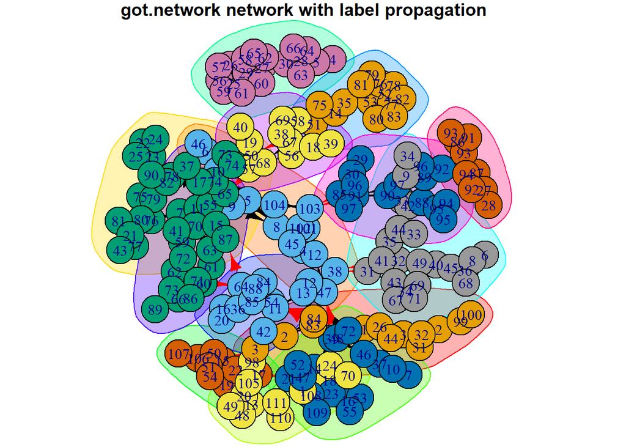

```r
par(mar=c(0,0,1,1))
plot(got.network.lp,
     got.network,
     vertex.color=membership(got.network.lp),
     vertex.label=seq(1:111),
     #vertex.label=NA,
     main="got.network network with label propagation")
```

### 1.6.4 Edge betweenness community detection

The partition suggested by this method involves the same as for the past methods some similar size communities, where the biggest ones are of size 22 and the smallest one of 9. Moreover, we do see some differences in the combination of characters in the groups, now we see a partition more similar to the Fast greedy method that combines some families for example, in group one is joinning the Arryn, with some of the Stark members.

```r
Start_time <- Sys.time()
got.network.eb <- cluster_edge_betweenness(sim.und.got.network,directed=FALSE)
got.network.eb
```

```
## IGRAPH clustering edge betweenness, groups: 12, mod: 0.84
## + groups:
##   $`1`
##    [1] "Lysa Arryn"       "Jasper Arryn"     "Jon Arryn"
##    [4] "Catelyn Stark"    "Eddard Stark"     "Minisa Whent"
##    [7] "Hoster Tully"     "Alys Arryn"       "Elys Waynwood"
##   [10] "Edmure Tully"     "Sansa Stark"      "Jeyne Westerling"
##   [13] "Talisa Stark"     "Petyr Baelish"    "Jeyne Royce"
##   [16] "Rowena Arryn"     "Robb Stark"       "Robert Arryn"
##   [19] "Arya Stark"       "Bran Stark"       "Rickon Stark"
##
##   $`2`
##   + ... omitted several groups/vertices
```

```r
End_time <- Sys.time()

print(paste('Time elapsed: ', (End_time-Start_time)))
```

```
## [1] "Time elapsed:  0.0857710838317871"
```

```r
length(got.network.eb)
```

```
## [1] 12
```

```r
sizes(got.network.eb)
```

```
## Community sizes
##  1  2  3  4  5  6  7  8  9 10 11 12
## 21 16 21 19 22 19 22 14 19 11 15  9
```

```r
membership(got.network.eb)
```

```
##                            Lysa Arryn                          Jasper Arryn
##                                     1                                     1
##                             Jon Arryn                      Cersei Lannister
##                                     1                                     2
##                     Cassana Baratheon                        Selyse Florent
##                                     2                                     2
##                     Rhaelle Targaryen                      Robert Baratheon
##                                     3                                     2
##                     Steffon Baratheon                     Stannis Baratheon
##                                     2                                     2
##                      Ormund Baratheon                       Jaime Lannister
##                                     3                                     2
##                          Mariya Darry                       Genna Lannister
##                                     4                                     5
##                         Bethany Rosby                           Jeyne Darry
##                                     4                                     5
##                           Perra Royce                           Dorna Swyft
##                                     4                                     5
##                      Amarei Crakehall                          Merrett Frey
##                                     4                                     4
##                            Emmon Frey                           Walder Frey
##                                     5                                     4
##                            Cleos Frey                       Kevan Lannister
##                                     5                                     5
##               Lady of House Stonetree                   Lady of House Piper
##                                     6                                     6
##                Lady of House Sunderly                        Alannys Harlaw
##                                     6                                     6
##                       Quellon Greyjoy                         Balon Greyjoy
##                                     6                                     6
##                         Marla Prester                       Alys Stackspear
##                                     7                                     7
##                          Cerissa Brax                       Myranda Lefford
##                                     7                                     7
##                        Rohanne Webber                      Shiera Crakehall
##                                     7                                     7
##                     Darlessa Marbrand                      Joanna Lannister
##                                     5                                     2
##                        Jeyne Marbrand                        Ella Lannister
##                                     5                                     7
```

[output cut: 153 more lines]

```
##                                     8                                     8
##                            Arya Stark                            Bran Stark
##                                     1                                     1
##                          Benjen Stark                              Jon Snow
##                                     9                                     9
##                          Rickon Stark                  Brandon Stark Burner
##                                     1                                     9
##                     Viserys Targaryen         Luthor Tyrell son of Theodore
##                                     3                                    12
##                        Medwick Tyrell                         Elinor Tyrell
##                                    12                                    12
##                        Hobber Redwyne                         Horas Redwyne
##                                    11                                    11
##                         Willas Tyrell                          Loras Tyrell
##                                    11                                    11
```

```r
modularity(got.network.eb)
```

```
## [1] 0.8359884
```

```r
method.compare[5,1]<- modularity(got.network.eb)
method.compare[5,2]<- length(sizes(got.network.eb))
method.compare[5,3]<-(End_time-Start_time)
```

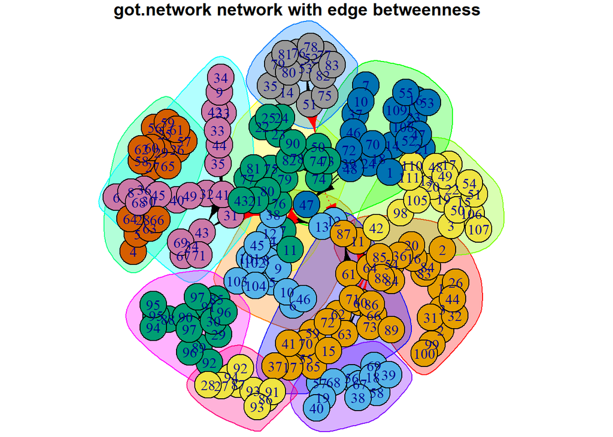

```r
par(mar=c(0,0,1,1))
plot(got.network.eb,
     got.network,
     vertex.color=membership(got.network.eb),
     vertex.label=seq(1:111),
     #vertex.label=NA,
     main="got.network network with edge betweenness")
```

### 1.6.5 Walktrap community detection

```r
Start_time <- Sys.time()
got.network.wa <- cluster_walktrap(got.network)
got.network.wa
```

```
## IGRAPH clustering walktrap, groups: 19, mod: 0.83
## + groups:
##   $`1`
##    [1] "Elia Martell"
##    [2] "Rhaegar Targaryen"
##    [3] "Shaera Targaryen"
##    [4] "Betha Blackwood"
##    [5] "Dyanna Dayne"
##    [6] "Rhaella Targaryen"
##    [7] "Jaehaerys II Targaryen"
##    [8] "Aegon V Targaryen"
##    [9] "Maekar I Targaryen"
##   + ... omitted several groups/vertices
```

```r
End_time <- Sys.time()

print(paste('Time elapsed: ', (End_time-Start_time)))
```

```
## [1] "Time elapsed:  0.0550081729888916"
```

```r
length(got.network.wa)
```

```
## [1] 19
```

```r
sizes(got.network.wa)
```

```
## Community sizes
##  1  2  3  4  5  6  7  8  9 10 11 12 13 14 15 16 17 18 19
## 19 21 15 25 24 15 13  9  4  7  7  5  3  6 12  4  4 10  5
```

```r
membership(got.network.wa)
```

```
##                            Lysa Arryn                          Jasper Arryn
##                                    14                                    13
##                             Jon Arryn                      Cersei Lannister
##                                    14                                     4
##                     Cassana Baratheon                        Selyse Florent
##                                     4                                     4
##                     Rhaelle Targaryen                      Robert Baratheon
##                                     4                                     4
##                     Steffon Baratheon                     Stannis Baratheon
##                                     4                                     4
##                      Ormund Baratheon                       Jaime Lannister
##                                     4                                     4
##                          Mariya Darry                       Genna Lannister
##                                     2                                     7
##                         Bethany Rosby                           Jeyne Darry
##                                     2                                     7
##                           Perra Royce                           Dorna Swyft
##                                     2                                     2
##                      Amarei Crakehall                          Merrett Frey
##                                     2                                     2
##                            Emmon Frey                           Walder Frey
##                                     7                                     2
##                            Cleos Frey                       Kevan Lannister
##                                     7                                     2
##               Lady of House Stonetree                   Lady of House Piper
##                                    15                                    15
##                Lady of House Sunderly                        Alannys Harlaw
##                                    15                                    11
##                       Quellon Greyjoy                         Balon Greyjoy
##                                    15                                    11
##                         Marla Prester                       Alys Stackspear
##                                     4                                     4
##                          Cerissa Brax                       Myranda Lefford
##                                    16                                    19
##                        Rohanne Webber                      Shiera Crakehall
##                                     4                                    12
##                     Darlessa Marbrand                      Joanna Lannister
##                                    17                                     4
##                        Jeyne Marbrand                        Ella Lannister
##                                     7                                     4
```

[output cut: 153 more lines]

```
##                                    18                                    18
##                            Arya Stark                            Bran Stark
##                                     5                                     5
##                          Benjen Stark                              Jon Snow
##                                     5                                     5
##                          Rickon Stark                  Brandon Stark Burner
##                                     5                                     5
##                     Viserys Targaryen         Luthor Tyrell son of Theodore
##                                     1                                     8
##                        Medwick Tyrell                         Elinor Tyrell
##                                     8                                     8
##                        Hobber Redwyne                         Horas Redwyne
##                                     3                                     3
##                         Willas Tyrell                          Loras Tyrell
##                                     3                                     3
```

```r
modularity(got.network.wa)
```

```
## [1] 0.8256053
```

```r
method.compare[6,1]<- modularity(got.network.wa)
method.compare[6,2]<- length(sizes(got.network.wa))
method.compare[6,3]<-(End_time-Start_time)
```

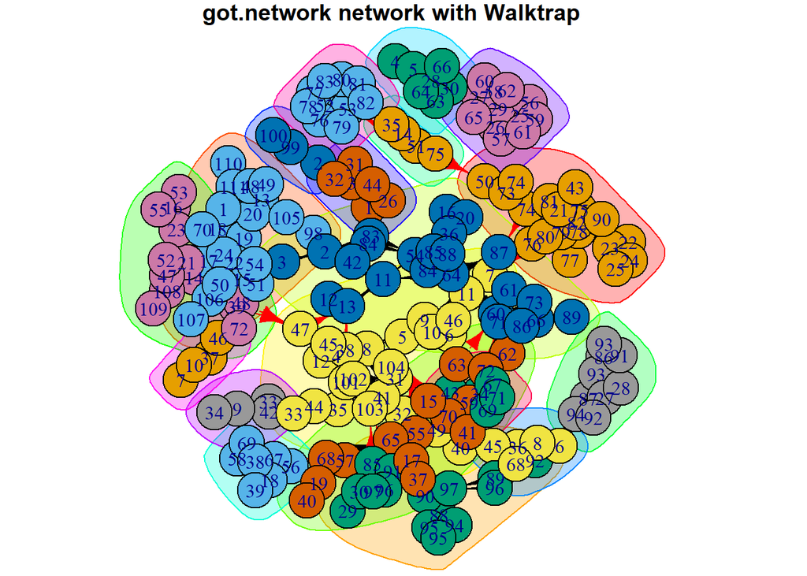

```r
par(mar=c(0,0,1,1))
plot(got.network.wa,
     got.network,
     vertex.color=membership(got.network.wa),
     vertex.label=seq(1:111),
     #vertex.label=NA,
     main="got.network network with Walktrap")
```

```r
library("pander")
pandoc.table(method.compare)
```

```
##
## --------------------------------------------------------
##         &nbsp;           Modularity   K    Time elapsed
## ----------------------- ------------ ---- --------------
##       **Optimal**            NA       NA        NA
##
##     **Fast greedy**        0.8234     11     0.00698
##
##       **Louvain**          0.8502     14     0.02394
##
##  **Label propagation**     0.8502     14     0.00698
##
##   **Edge betweeness**      0.836      12     0.08577
##
##      **Walktrap**          0.8256     19     0.05501
## --------------------------------------------------------
```

## 1.7 Assortativity coefficient.

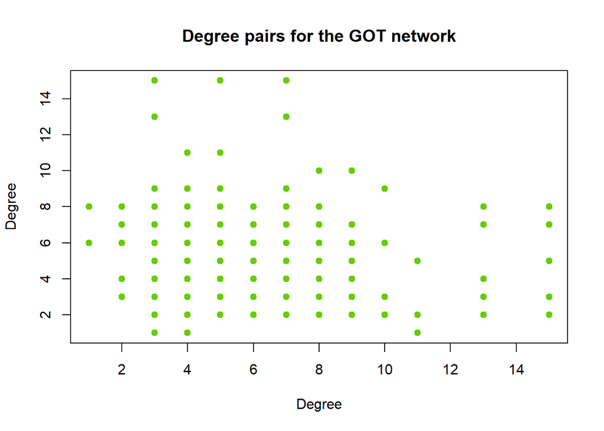

```r
degree.got.network <- igraph::degree(got.network)
got.network.degrees <- matrix(NA,nrow=ecount(got.network),ncol=2)
edges.got.network <- get.edgelist(got.network)
for (i in 1:ecount(got.network)){got.network.degrees[i,]<-degree.got.network[edges.got.network[i,]]}
plot(got.network.degrees,pch=19,col="chartreuse3",main="Degree pairs for the GOT network",
     xlab="Degree",ylab="Degree")
```

```r
assortativity_degree(got.network,V(got.network))
```

```
## [1] -0.1901089
```